# Exploratory Data Analysis of Red Wine Quality by John Ingles

Next, I’ll look at distributions of the independent variables. I’ll start with the acidity values.

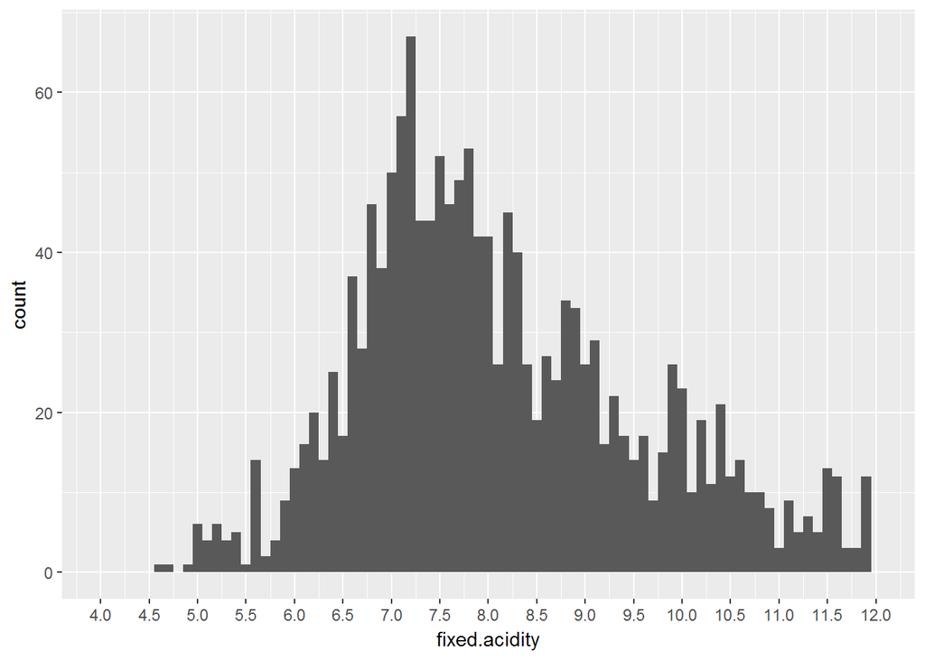

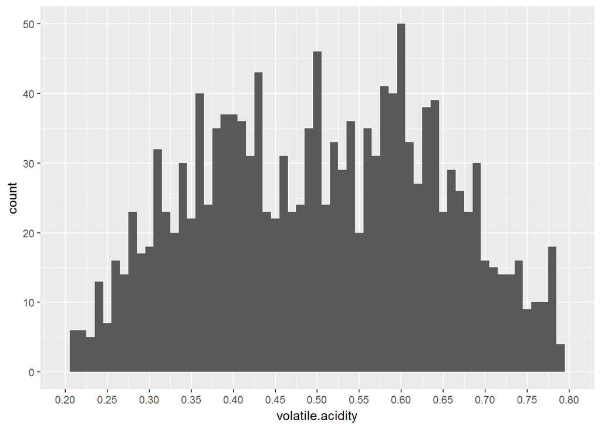

Fixed acidity is right skewed while volatile acidity is more centered and slightly bimodal. Fixed acidity values around 7 g/L are most numerous, while volatile acidity values are more spread out and centered around 0.5 g/L. Both values have a few high valued outliers.

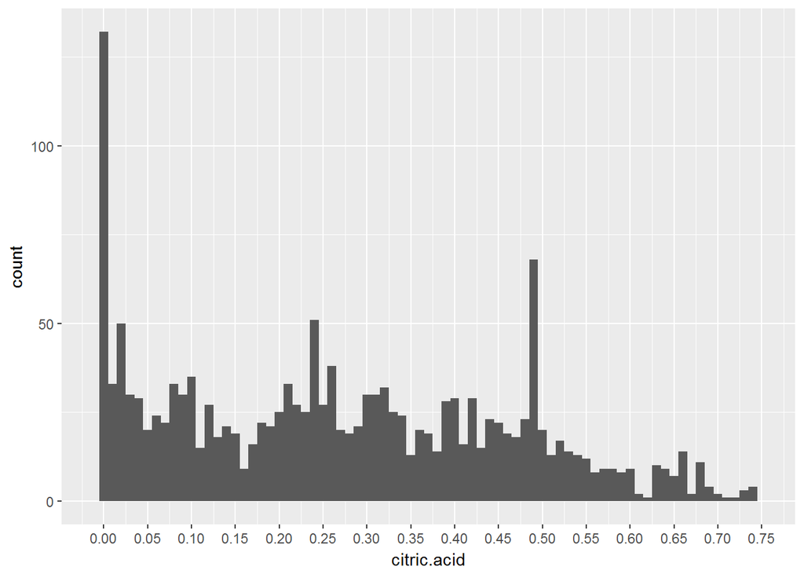

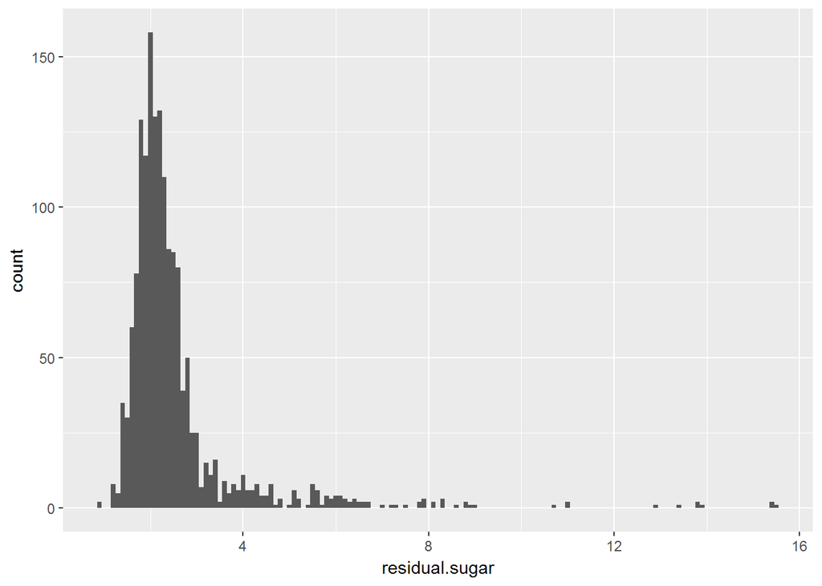

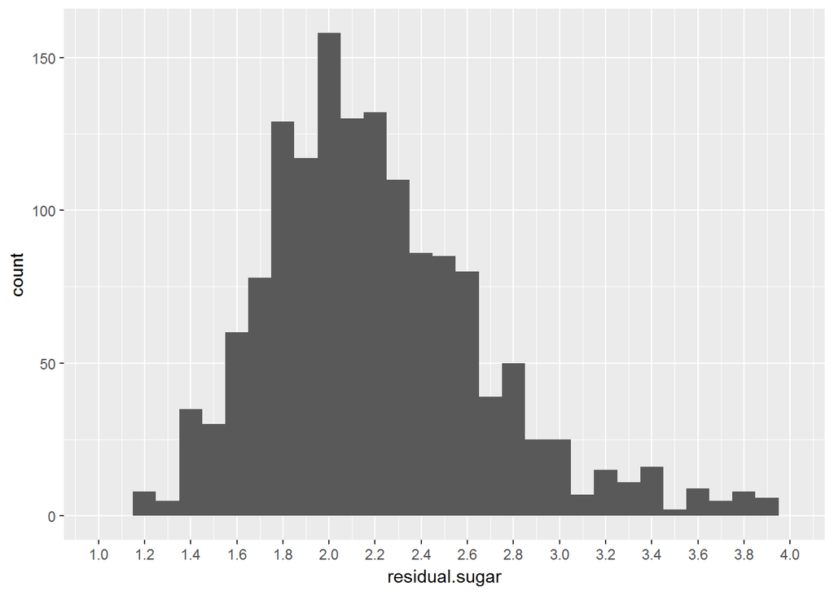

After zooming in past the outliers we see a normal distribution centered around 2 g/L with a width of about 1 g/L for the residual sugar counts.

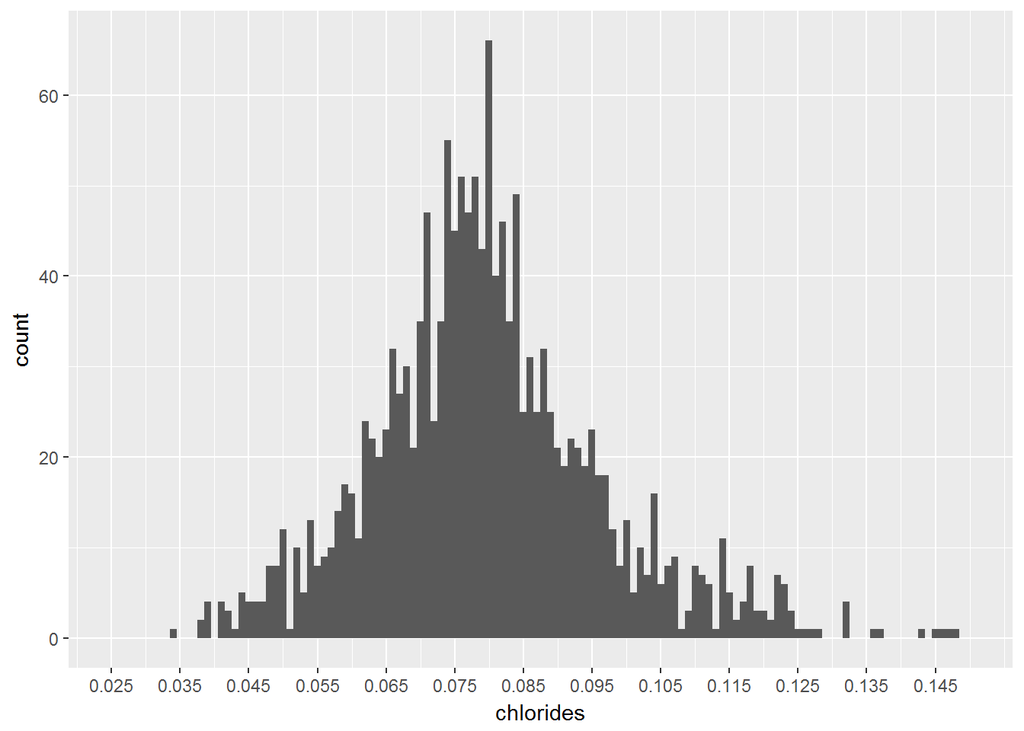

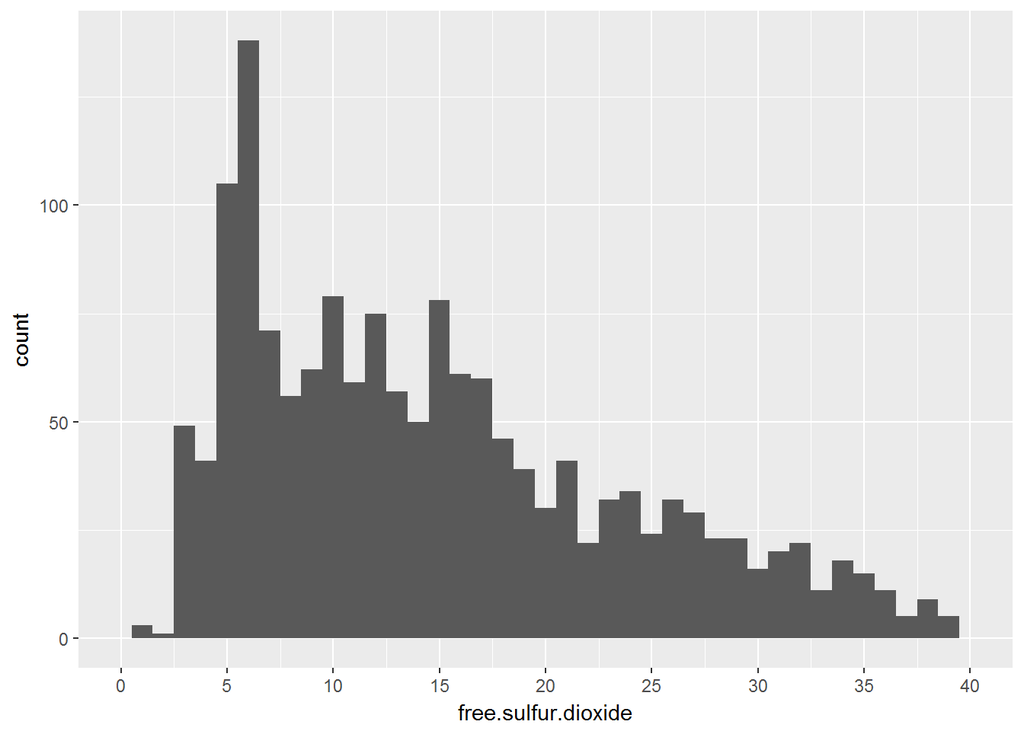

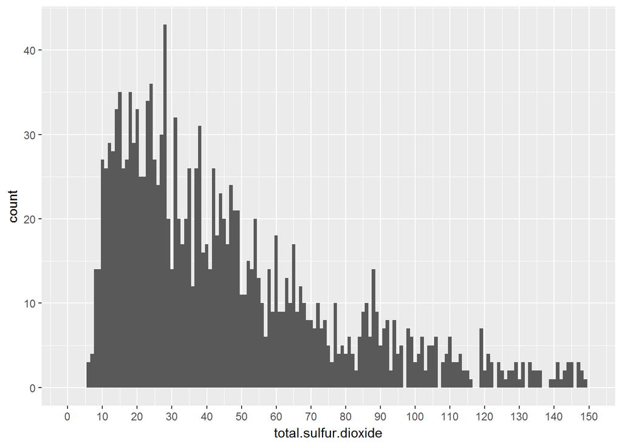

The free and total sulfur dioxides are both right skewed distributions with peaks around 5 mg/L and 25 mg/L respectively.

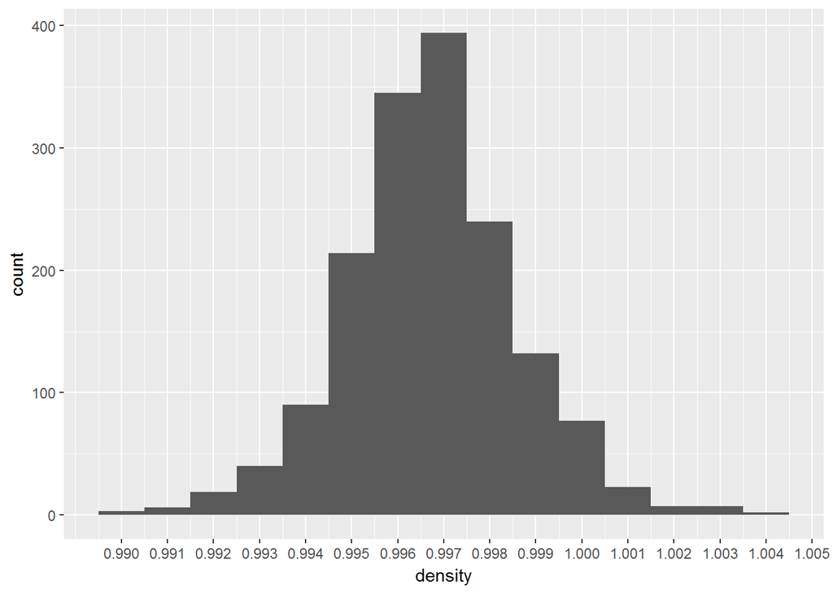

```
##    Min. 1st Qu.  Median    Mean 3rd Qu.    Max.
##  0.9901  0.9956  0.9968  0.9967  0.9978  1.0037
```

The density of the wines are normally distributed around a mean of 0.9967 with a width of about 0.0025 g/mL.

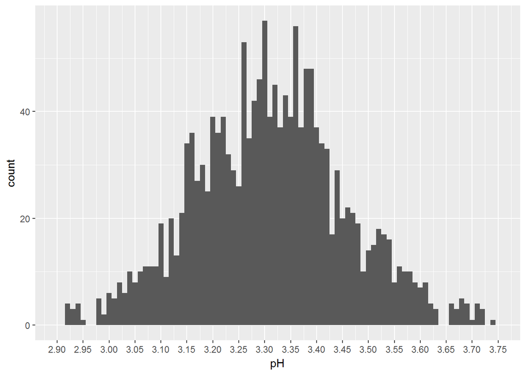

```
##    Min. 1st Qu.  Median    Mean 3rd Qu.    Max.
##   2.740   3.210   3.310   3.311   3.400   4.010
```

Ph is also normally distributed for the most part with a mean of 3.311 and a width of about 0.25.

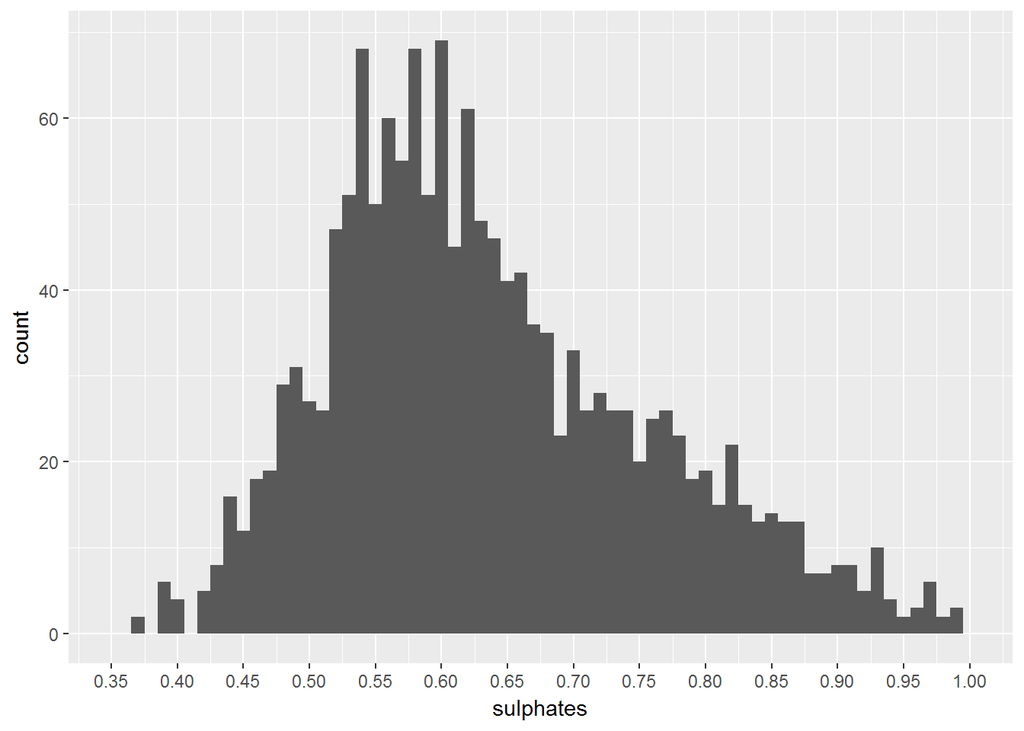

The sulphates measurements are slightly right skewed with a peak at about 0.6 g/L and numerous outliers to the right.

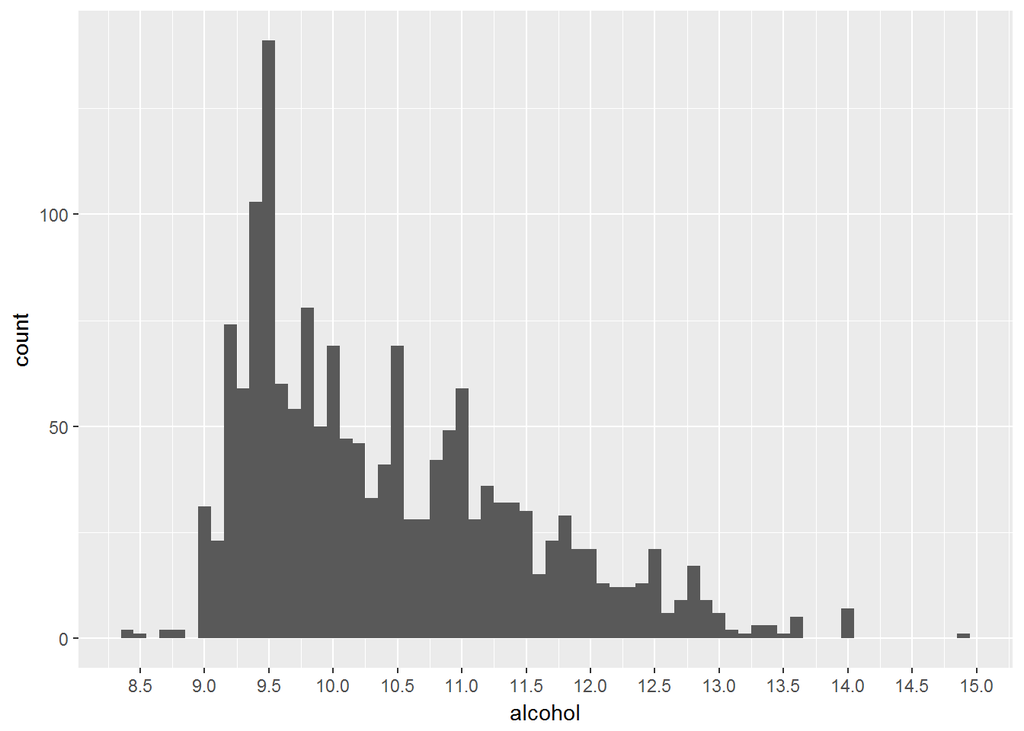

Finally, The alcohol percentages of the samples are right skewed with a peak at about 9.5% by volume.

### What is the structure of your dataset?

There are 1599 wine samples in the data set with 11 variables

1. fixed acidity (tartaric acid - g / dm^3)
2. volatile acidity (acetic acid - g / dm^3)
3. citric acid (g / dm^3)
4. residual sugar (g / dm^3)
5. chlorides (sodium chloride - g / dm^3
6. free sulfur dioxide (mg / dm^3)
7. total sulfur dioxide (mg / dm^3)
8. density (g / cm^3)
9. pH
10. sulphates (potassium sulphate - g / dm3)
11. alcohol (% by volume)

### What is/are the main feature(s) of interest in your dataset?

The main feature in the data set is quality rating. It’s my aim to determine which factors are best for predicting the quality of the wine. Based on the info sheet for the source of the data, I suspect volatile acidity, citric acid, sulphates, and alcohol content will have the most effect on taste.

### What other features in the dataset do you think will help support your investigation into your feature(s) of interest?

Other features which I suspect could possibly affect the quality of the wine are free sulfur dioxide, ph, and residual sugar.

### Did you create any new variables from existing variables in the dataset?

No new variables were created.

### Of the features you investigated, were there any unusual distributions? Did you perform any operations on the data to tidy, adjust, or change the form of the data? If so, why did you do this?

I rescaled the plot for residual sugar since its distribution was narrow with many outliers.

# Bivariate Plots Section

```
##         fa    va    ca    rs   chl   fsd   tsd   den    ph   sul   alc
## fa    1.00 -0.26  0.67  0.11  0.09 -0.15 -0.11  0.67 -0.68  0.18 -0.06
## va   -0.26  1.00 -0.55  0.00  0.06 -0.01  0.08  0.02  0.23 -0.26 -0.20
## ca    0.67 -0.55  1.00  0.14  0.20 -0.06  0.04  0.36 -0.54  0.31  0.11
## rs    0.11  0.00  0.14  1.00  0.06  0.19  0.20  0.36 -0.09  0.01  0.04
## chl   0.09  0.06  0.20  0.06  1.00  0.01  0.05  0.20 -0.27  0.37 -0.22
## fsd  -0.15 -0.01 -0.06  0.19  0.01  1.00  0.67 -0.02  0.07  0.05 -0.07
## tsd  -0.11  0.08  0.04  0.20  0.05  0.67  1.00  0.07 -0.07  0.04 -0.21
## den   0.67  0.02  0.36  0.36  0.20 -0.02  0.07  1.00 -0.34  0.15 -0.50
## ph   -0.68  0.23 -0.54 -0.09 -0.27  0.07 -0.07 -0.34  1.00 -0.20  0.21
## sul   0.18 -0.26  0.31  0.01  0.37  0.05  0.04  0.15 -0.20  1.00  0.09
## alc  -0.06 -0.20  0.11  0.04 -0.22 -0.07 -0.21 -0.50  0.21  0.09  1.00
## qual  0.12 -0.39  0.23  0.01 -0.13 -0.05 -0.19 -0.17 -0.06  0.25  0.48
##       qual
## fa    0.12
## va   -0.39
## ca    0.23
## rs    0.01
## chl  -0.13
## fsd  -0.05
## tsd  -0.19
## den  -0.17
## ph   -0.06
## sul   0.25
## alc   0.48
## qual  1.00
```

Citric acid and fixed acid have a correlation of 0.67, likely owing to citric acid itself being an acid. Fixed acid also appears to correlate positively with density and negatively with ph. Free sulfur dioxide and total sulfur dioxide also have a correlation of 0.67, which makes sense since they are recording different measures of the same chemical. As far as features directly correlating with quality, the highest were volatile acidity with -0.39 and alcohol content with 0.48.

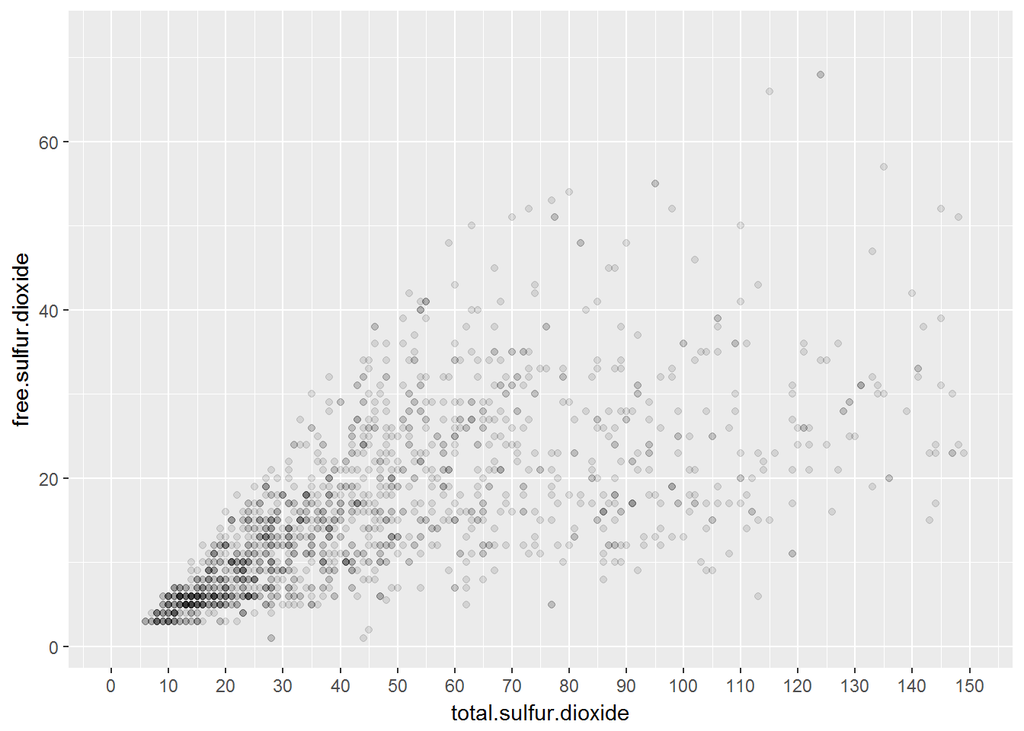

The ratio of free to total sulfur dioxide is strictly under 0.80 and there appears to be a slight linear relationship between them as expected.

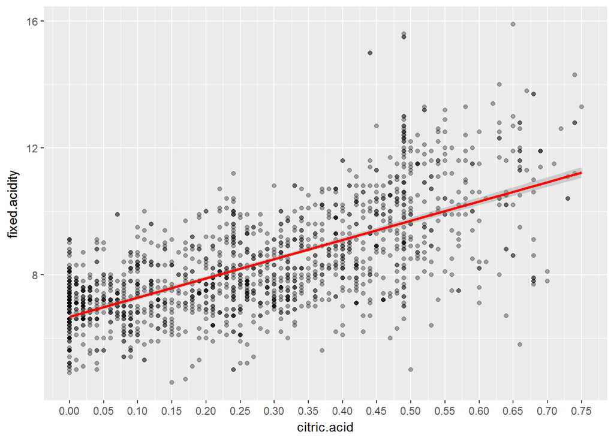

The relationship between citric acid and fixed acidity is decidedly more linear.

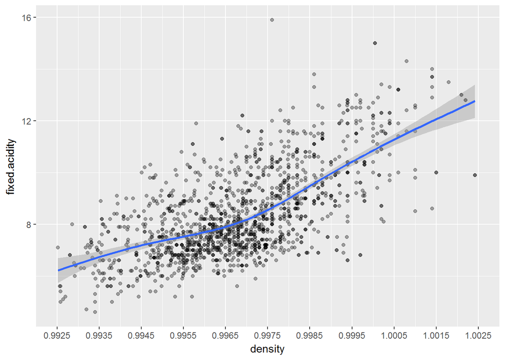

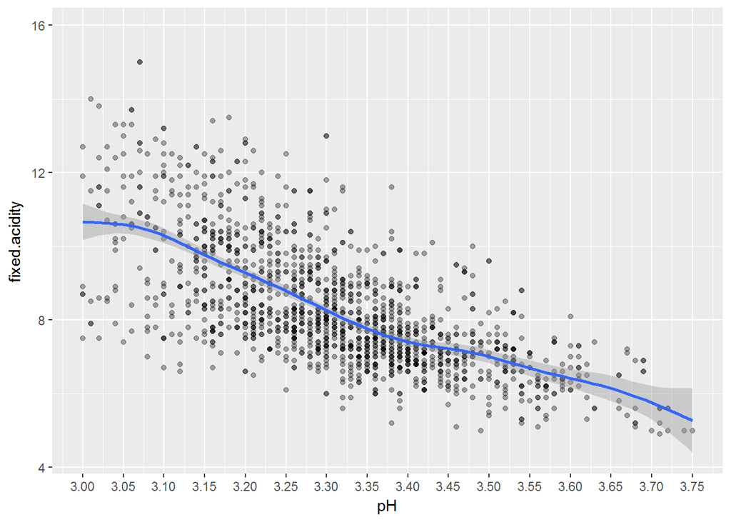

Density and ph also show a relationship to fixed acidity, with density generally being higher for higher fixed acidity and ph being lower as expected.

Finally, I’ll use box plots to get an idea of the effect on quality for each of the supporting features.

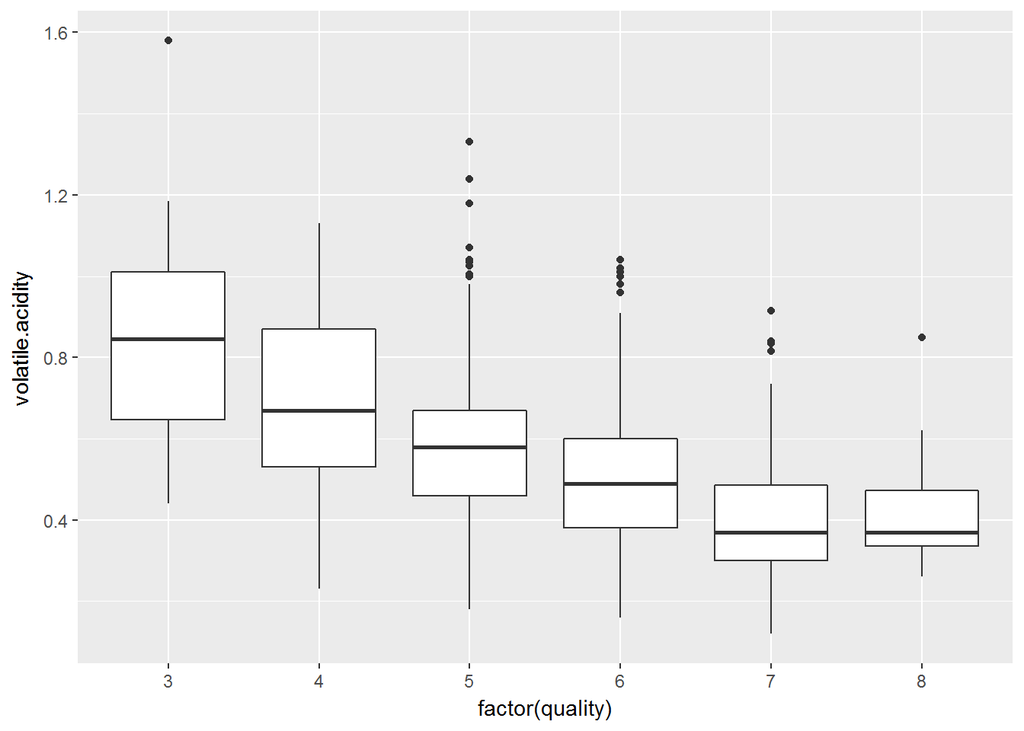

```
## rw_data$quality: 3
##    Min. 1st Qu.  Median    Mean 3rd Qu.    Max.
##  0.4400  0.6475  0.8450  0.8845  1.0100  1.5800
## --------------------------------------------------------
## rw_data$quality: 4
##    Min. 1st Qu.  Median    Mean 3rd Qu.    Max.
##   0.230   0.530   0.670   0.694   0.870   1.130
## --------------------------------------------------------
## rw_data$quality: 5
##    Min. 1st Qu.  Median    Mean 3rd Qu.    Max.
##   0.180   0.460   0.580   0.577   0.670   1.330
## --------------------------------------------------------
## rw_data$quality: 6
##    Min. 1st Qu.  Median    Mean 3rd Qu.    Max.
##  0.1600  0.3800  0.4900  0.4975  0.6000  1.0400
## --------------------------------------------------------
## rw_data$quality: 7
##    Min. 1st Qu.  Median    Mean 3rd Qu.    Max.
##  0.1200  0.3000  0.3700  0.4039  0.4850  0.9150
## --------------------------------------------------------
## rw_data$quality: 8
##    Min. 1st Qu.  Median    Mean 3rd Qu.    Max.
##  0.2600  0.3350  0.3700  0.4233  0.4725  0.8500
```

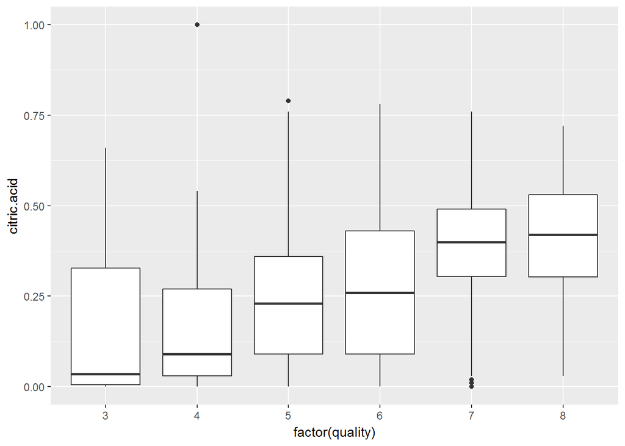

```
## rw_data$quality: 3
##    Min. 1st Qu.  Median    Mean 3rd Qu.    Max.
##  0.0000  0.0050  0.0350  0.1710  0.3275  0.6600
## --------------------------------------------------------
## rw_data$quality: 4
##    Min. 1st Qu.  Median    Mean 3rd Qu.    Max.
##  0.0000  0.0300  0.0900  0.1742  0.2700  1.0000
## --------------------------------------------------------
## rw_data$quality: 5
##    Min. 1st Qu.  Median    Mean 3rd Qu.    Max.
##  0.0000  0.0900  0.2300  0.2437  0.3600  0.7900
## --------------------------------------------------------
## rw_data$quality: 6
##    Min. 1st Qu.  Median    Mean 3rd Qu.    Max.
##  0.0000  0.0900  0.2600  0.2738  0.4300  0.7800
## --------------------------------------------------------
## rw_data$quality: 7
##    Min. 1st Qu.  Median    Mean 3rd Qu.    Max.
##  0.0000  0.3050  0.4000  0.3752  0.4900  0.7600
## --------------------------------------------------------
## rw_data$quality: 8
##    Min. 1st Qu.  Median    Mean 3rd Qu.    Max.
##  0.0300  0.3025  0.4200  0.3911  0.5300  0.7200
```

The IQR is pretty wide for several quality values such as 3 and 6, but just looking at the medians and means we can still see a trend of increasing quality for increasing levels of citric acid.

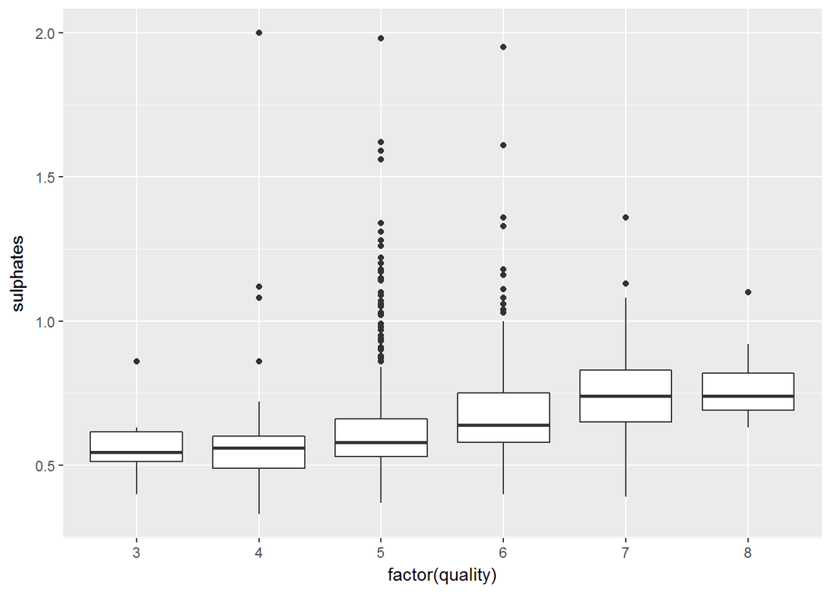

```
## rw_data$quality: 3
##    Min. 1st Qu.  Median    Mean 3rd Qu.    Max.
##  0.4000  0.5125  0.5450  0.5700  0.6150  0.8600
## --------------------------------------------------------
## rw_data$quality: 4
##    Min. 1st Qu.  Median    Mean 3rd Qu.    Max.
##  0.3300  0.4900  0.5600  0.5964  0.6000  2.0000
## --------------------------------------------------------
## rw_data$quality: 5
##    Min. 1st Qu.  Median    Mean 3rd Qu.    Max.
##   0.370   0.530   0.580   0.621   0.660   1.980
## --------------------------------------------------------
## rw_data$quality: 6
##    Min. 1st Qu.  Median    Mean 3rd Qu.    Max.
##  0.4000  0.5800  0.6400  0.6753  0.7500  1.9500
## --------------------------------------------------------
## rw_data$quality: 7
##    Min. 1st Qu.  Median    Mean 3rd Qu.    Max.
##  0.3900  0.6500  0.7400  0.7413  0.8300  1.3600
## --------------------------------------------------------
## rw_data$quality: 8
##    Min. 1st Qu.  Median    Mean 3rd Qu.    Max.
##  0.6300  0.6900  0.7400  0.7678  0.8200  1.1000
```

The effect of sulphate additives on the quality of the wine samples seems about the same as that of citric acid, but the IQR’s are much smaller. This points to the effect of sulphates on quality as being more certain than that citric acid.

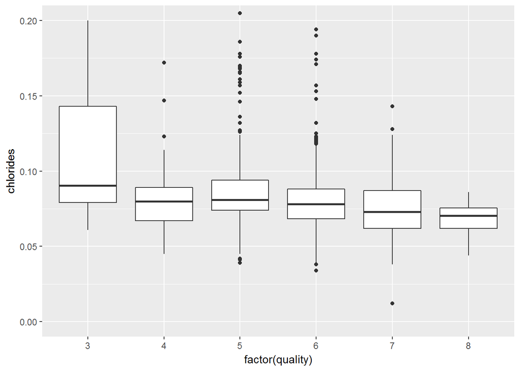

I had to scale this one down because there were many high chloride outliers. Even after this, there’s only a slight difference in quality as the level of chlorides decreases.

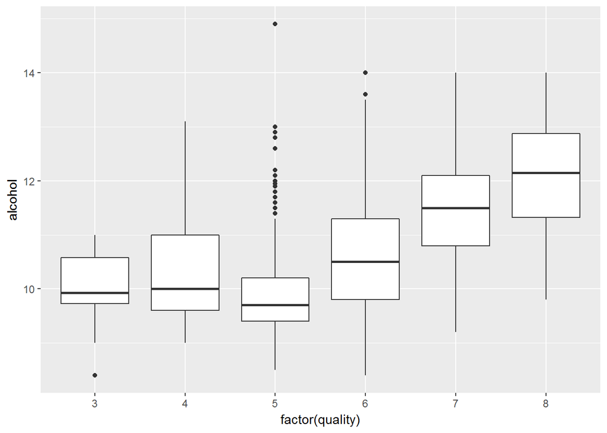

```
## rw_data$quality: 3
##    Min. 1st Qu.  Median    Mean 3rd Qu.    Max.
##   8.400   9.725   9.925   9.955  10.575  11.000
## --------------------------------------------------------
## rw_data$quality: 4
##    Min. 1st Qu.  Median    Mean 3rd Qu.    Max.
##    9.00    9.60   10.00   10.27   11.00   13.10
## --------------------------------------------------------
## rw_data$quality: 5
##    Min. 1st Qu.  Median    Mean 3rd Qu.    Max.
##     8.5     9.4     9.7     9.9    10.2    14.9
## --------------------------------------------------------
## rw_data$quality: 6
##    Min. 1st Qu.  Median    Mean 3rd Qu.    Max.
##    8.40    9.80   10.50   10.63   11.30   14.00
## --------------------------------------------------------
## rw_data$quality: 7
##    Min. 1st Qu.  Median    Mean 3rd Qu.    Max.
##    9.20   10.80   11.50   11.47   12.10   14.00
## --------------------------------------------------------
## rw_data$quality: 8
##    Min. 1st Qu.  Median    Mean 3rd Qu.    Max.
##    9.80   11.32   12.15   12.09   12.88   14.00
```

Low levels of alcohol around 10% by volume seem equally distributed at quality levels of 3, 4 and 5. After that, there is an increasing trend in quality for samples with higher levels of alcohol with levels of around 12% being judged to have the highest quality.

# Bivariate Analysis

### Talk about some of the relationships you observed in this part of the investigation. How did the feature(s) of interest vary with other features in the data set?

There is a relatively high correlation between citric acid and fixed acidity of 0.67. While there are no correlations over 0.60 for volatile acidity or alcohol.

A plot of citric acid vs. fixed acidity shows what appears to be a linear relationship, although it’s hard to tell for sure with the relatively low number of data points.

Box plots of volatile acidity, citric acid, sulphates, and alcohol across quality show a positive influence on quality for alcohol, citric acid and sulphates, and a negative influence for volatile acidity.

In addition, the box plot of chlorides across quality shows a slight relationship. Along with the correlation between quality and chlorides of -0.13, I think there is enough evidence to consider the effect of chlorides on the quality along with the main features.

### Did you observe any interesting relationships between the other features (not the main feature(s) of interest)?

I observed several correlations between the other features:

| Variables | Correlation |
| --- | --- |
| free.sulfur.dioxide vs. total.sulfur.dioxide | 0.67 |
| density vs. fixed.acidity | 0.67 |
| pH vs. fixed.acidity | -0.68 |

Plots of these also showed what appeared to be linear relationships.

### What was the strongest relationship you found?

I judged the strongest relationship to be the one between alcohol and quality based on the correlation of 0.48, along with the trend shown in the set of box plots of the two variables.

# Multivariate Plots Section

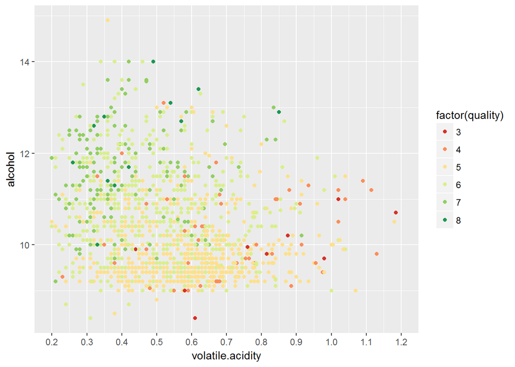

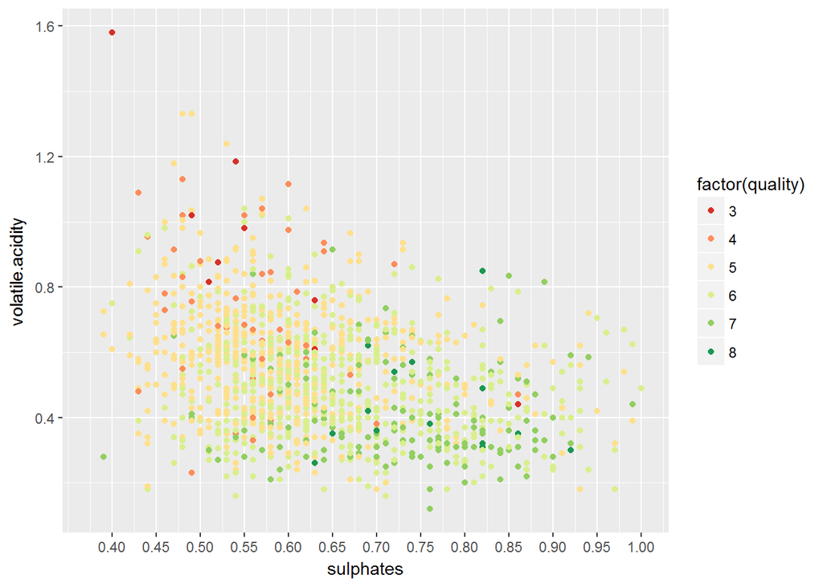

I then did the same with sulphates instead of alcohol and found a similar result.

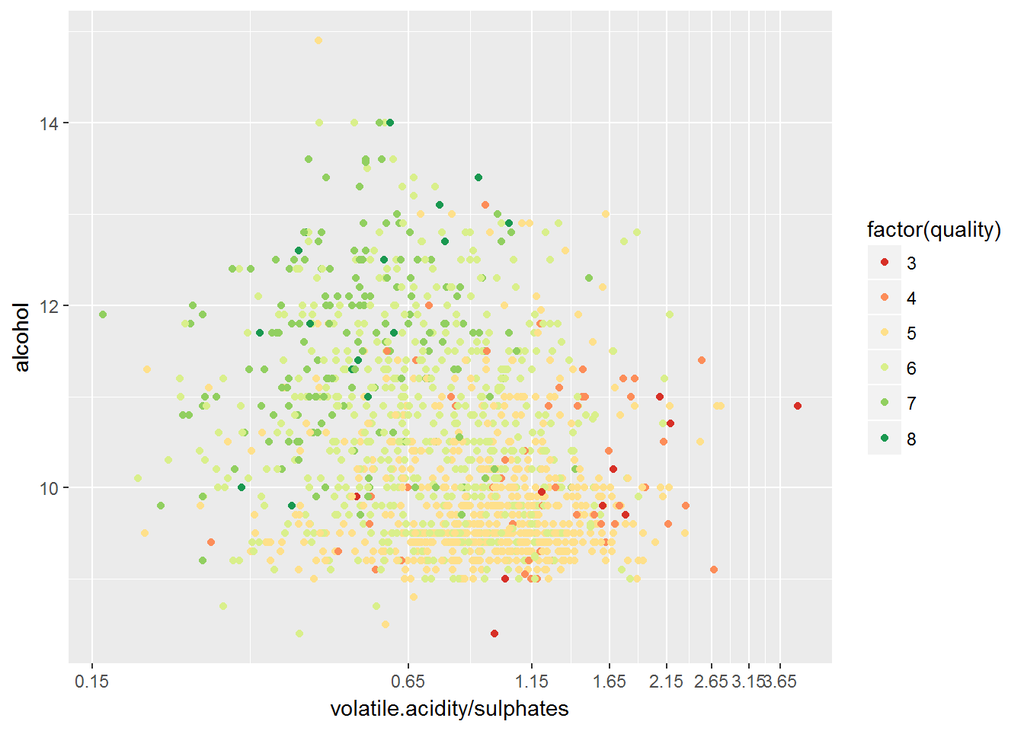

Combining volatile acidity and sulphates with a ratio, applying a log function, and plotting it against alcohol results in a graph that looks to be the beginnings of a predictive model for quality. The divides between good and bad samples are still clear which means the factors aren’t interfering with each other.

The quality results are ordinal so I will use an Ordinal Logistic Regression to build a model based on the features.

```
## Call:
## polr(formula = quality.f ~ alcohol + volatile.acidity + sulphates,
##     data = rw_data, Hess = TRUE)
##
## Coefficients:
##                    Value Std. Error t value
## alcohol           0.9374    0.05441  17.229
## volatile.acidity -3.6191    0.31738 -11.403
## sulphates         2.1427    0.31732   6.753
##
## Intercepts:
##     Value    Std. Error t value
## 3|4   3.4313   0.7048     4.8682
## 4|5   5.3586   0.6397     8.3768
## 5|6   8.9841   0.6417    14.0013
## 6|7  11.7561   0.6820    17.2388
## 7|8  14.7458   0.7402    19.9211
##
## Residual Deviance: 3138.035
## AIC: 3154.035
```

```
##                       Value Std..Error    t.value pval
## alcohol           0.9374265 0.05441002  17.228930    0
## volatile.acidity -3.6190824 0.31737869 -11.403042    0
## sulphates         2.1427003 0.31731635   6.752568    0
## 3|4               3.4312799 0.70483844   4.868179    0
## 4|5               5.3585665 0.63969091   8.376806    0
## 5|6               8.9840834 0.64166285  14.001252    0
## 6|7              11.7561145 0.68195599  17.238817    0
## 7|8              14.7457955 0.74021101  19.921070    0
```

```
##          alcohol volatile.acidity        sulphates
##       2.55340181       0.02680726       8.52241989
```

After running an Ordinal Logistic Regression with alcohol, volatile acidity, and sulphates as predictors, I get a model that explains the data with high significance as shown by the p-values shown at 0. I tried adding other variables to the model, but most caused no significant change to the Residual Deviance or AIC. Adding citric acid caused a slight improvement, but unexpectedly it had a fractional odds ratio indicating a negative correlation with quality. Since this went against the previous box plot of citric acid versus quality and the p value was around 0.20, I dropped it from the model.

# Multivariate Analysis

### Were there any interesting or surprising interactions between features?

In an unused logit model, citric acid had a negative effect on quality, even though a box plot of citric acid across quality showed a slight positive effect.

### OPTIONAL: Did you create any models with your dataset? Discuss the strengths and limitations of your model.

Yes, I created a model using Ordinal Logistic Regression with alcohol percentage, volatile acidity levels, and sulphate levels as predictors.

This test shows that there is a significant lack of evidence to support the null hypothesis. This is shown by low p-values for each predictor and a residual deviance of 3138.035 for a system with 1599 degrees of freedom.

```r
pval<-1-pchisq(3138.035, 1599)
pval
```

```
## [1] 0
```

# Final Plots and Summary

### Plot One

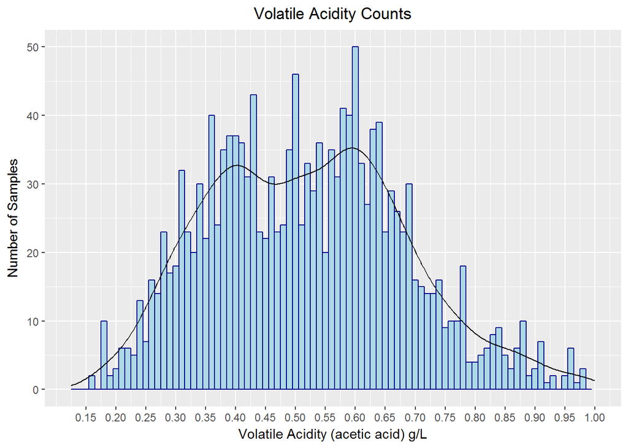

### Description One

The distribution of volatile acidity values is slightly bimodal. The peaks are around 0.40 g/L and 0.60 g/L. There is a small third peak in the center around 0.50 g/L. The mean is 0.53 g/L and the median is 0.52 g/L.

### Plot Two

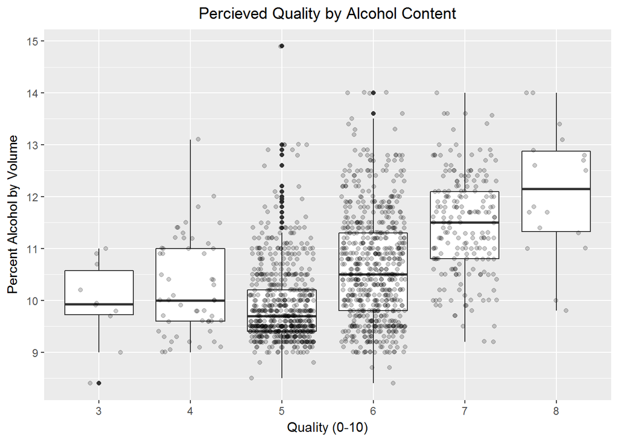

### Description Two

The samples with high alcohol content show an increase in perceived quality after around 10% alcohol by volume. Most values are found in the 5, 6, and 7 categories, while comparatively fewer are found in the 3, 4, and 8 categories.

### Plot Three

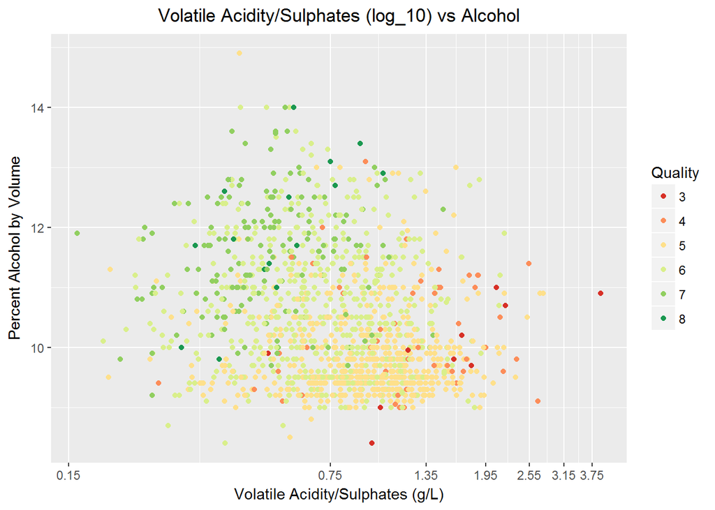

# Reflection

The red wine data set contains 1599 observations across 11 variables. I made histograms of each variable to understand their distributions, looked for correlations between variables, and used box plots to check the effect of each variable on quality. Finally, I used an Ordinal Logistic Regression with the variables that most affected the wine quality as predictors.

The correlations pointed to volatile acidity, alcohol, sulphates, and citric acid being the factors that most affected quality. All the other factors had correlations below 0.20. Also, based on what I read in the information sheet that came with the data, each of these factors have well understood mechanisms that affect the taste of red wine. The box plots also supported the correlations so I tried creating several models using combinations of these variables as predictors. Volatile acidity, alcohol, and sulphates together as predictors all had p-values near zero, but the p-value of citric acid when it was added on was around 0.20 and it didn’t have any significant effect on the residual deviance. Also, surprisingly, the correlation was negative in contradiction to the previously found trend. These issues led to citric acid being dropped from the model.

If this analysis were to be repeated, I would like there to be some improvements made to the data. The quality of each sample was said, in the information sheet, to be based on the median evaluation of at least three experts. I think it would be better to increase the number of evaluations to each sample in order to minimize bias. I would also like to see more data points in general than 1599. For example, the same study done using white wine had over 4,000 samples. The model in this analysis could be applied to this new data set to test its accuracy.

# Citation

[1] P. Cortez, A. Cerdeira, F. Almeida, T. Matos and J. Reis. Modeling wine preferences by data mining from physicochemical properties. In Decision Support Systems, Elsevier, 47(4):547-553. ISSN: 0167-9236.